# An Introduction to Statistical Learning (2013)

Solutions to Applied Exercises

by Brian Hassett

# Chapter 6 Linear Model Selection and Regularization

This notebook is a rough outline of solutions to the applied exercises in Chapter 6 of **An Introduction to Statistical Learning** (James et al. (2013)[^1]).

## Setup

```r
library(ISLR)
library(MASS)
library(glmnet)
library(leaps)
library(pls)
library(tidyverse)
library(patchwork)
theme_set(theme_bw())

# Given a filename, return the filepath. Default folder is the `data` folder in the current working directory.
get_path <- function(filename) {
  str_c(getwd(), "data", filename, sep = "/")
}

# Colors:
ISLR_blue <- "#176FC0"
ISLR_brown <- "#94340E"
ISLR_lightblue <- "#68A5DB"
ISLR_orange <- "#CC5318"

# Return vector of the names of numeric columns in a data frame:
numeric_cols <- function(df) {
  is_numeric_cols <- map_lgl(df, is.numeric)
  return(names(df)[is_numeric_cols])
}

# predict() function for regsubsets() as given in the book:
predict.regsubsets <- function(object, newdata, id,...) {
  form <- as.formula(object$call[[2]])
  mat <- model.matrix(form, newdata)
  coefi <- coef(object, id=id)
  xvars <- names(coefi)
  mat[, xvars]%*%coefi
}

# Print accuracy, test rate and table of predicted labels and true labels:
test_rates <- function(predicted_label, test_label) {
  print(table(predicted_label, test_label))
  test_accuracy <- mean(predicted_label == test_label)*100
  test_error <- mean(predicted_label != test_label)*100
  print(str_interp("Test accuracy: ${round(test_accuracy, 2)}"))
  print(str_interp("Test error rate: ${round(test_error, 2)}"))
}
```

## Exercise 8

### (a)

Generate data:

```r
set.seed(1)
n <- 100
x <- rnorm(n)
eps <- rnorm(n, sd = 0.7)
```

### (b)

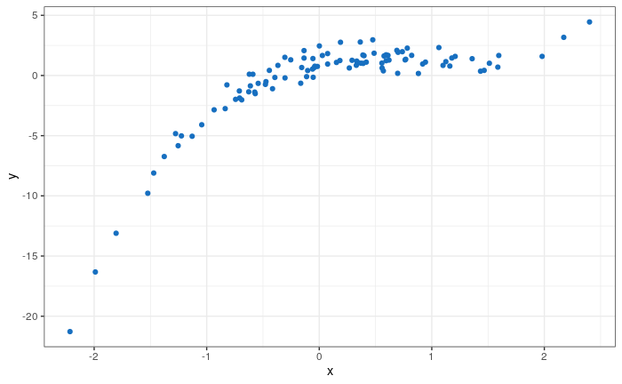

```r
beta0 <-  1
beta1 <- 1.5
beta2 <- -2
beta3 <-  0.8
beta <- c(beta0, beta1, beta2, beta3)
names(beta) <- c("Int", "x^1", "x^2", "x^3")

y <- beta0 + beta1*x + beta2*x^2 + beta3*x^3 + eps

tibble(x, y) %>%
  ggplot(aes(x, y)) +
  geom_point(color = ISLR_blue)
```

### (c)

```r
# Create a matrix X = x^1, x^2, x^3,..., x^10
p = 10
X <- x
for(i in 2:p) {
  x_i <- x^i
  X <- cbind(X, x_i)
}

colnames(X) <- paste0("x^", 1:p)
data <- data.frame(X, y)
```

### Best Subset Selection

```r
best <- regsubsets(y ~ ., data, nvmax = 10)
best_summary <- summary(best)
best_summary
```

```
Subset selection object
Call: regsubsets.formula(y ~ ., data, nvmax = 10)
10 Variables  (and intercept)
     Forced in Forced out
x.1      FALSE      FALSE
x.2      FALSE      FALSE
x.3      FALSE      FALSE
x.4      FALSE      FALSE
x.5      FALSE      FALSE
x.6      FALSE      FALSE
x.7      FALSE      FALSE
x.8      FALSE      FALSE
x.9      FALSE      FALSE
x.10     FALSE      FALSE
1 subsets of each size up to 10
Selection Algorithm: exhaustive
          x.1 x.2 x.3 x.4 x.5 x.6 x.7 x.8 x.9 x.10
1  ( 1 )  "*" " " " " " " " " " " " " " " " " " "
2  ( 1 )  " " "*" "*" " " " " " " " " " " " " " "
3  ( 1 )  "*" "*" "*" " " " " " " " " " " " " " "
4  ( 1 )  "*" "*" "*" " " "*" " " " " " " " " " "
5  ( 1 )  "*" "*" "*" " " "*" "*" " " " " " " " "
6  ( 1 )  "*" "*" "*" " " " " " " "*" "*" "*" " "
7  ( 1 )  "*" "*" "*" " " "*" "*" " " "*" " " "*"
8  ( 1 )  "*" "*" "*" "*" " " "*" " " "*" "*" "*"
9  ( 1 )  "*" "*" " " "*" "*" "*" "*" "*" "*" "*"
10  ( 1 ) "*" "*" "*" "*" "*" "*" "*" "*" "*" "*"
```

Plot the error metrics:

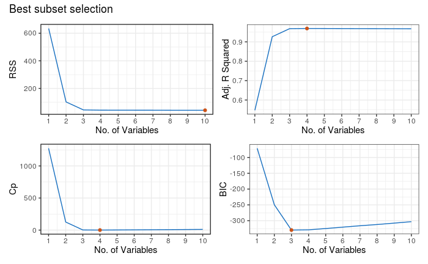

```r
p <- length(best_summary$rss)
summary <- data.frame(
  p = 1:p,
  rss = best_summary$rss,
  adjr2 = best_summary$adjr2,
  cp = best_summary$cp,
  bic = best_summary$bic)

p1 <- summary %>%
  ggplot(aes(p, rss)) +
  geom_line(color = ISLR_blue) +
  geom_point(data = summary[which.min(summary$rss), ],
             color = ISLR_orange) +
  scale_x_continuous(breaks = 1:10) +
  labs(x = "No. of Variables", y = "RSS")

p2 <- summary %>%
  ggplot(aes(p, adjr2)) +
  geom_line(color = ISLR_blue) +
  geom_point(data = summary[which.max(summary$adjr2), ],
             color = ISLR_orange) +
  scale_x_continuous(breaks = 1:10) +
  labs(x = "No. of Variables", y = "Adj. R Squared")

p3 <- summary %>%
  ggplot(aes(p, cp)) +
  geom_line(color = ISLR_blue) +
  geom_point(data = summary[which.min(summary$cp), ],
             color = ISLR_orange) +
  scale_x_continuous(breaks = 1:10) +
  labs(x = "No. of Variables", y = "Cp")

p4 <- summary %>%
  ggplot(aes(p, bic)) +
  geom_line(color = ISLR_blue) +
  geom_point(data = summary[which.min(summary$bic), ],
             color = ISLR_orange) +
  scale_x_continuous(breaks = 1:10) +
  labs(x = "No. of Variables", y = "BIC")

(p1 + p2) / (p3 + p4) + plot_annotation(title = "Best subset selection")
```

#### $C_p$

The model with the lowest $C_p$:

```r
str_interp("No. of variables: ${which.min(best_summary$cp)}")
```

```
[1] "No. of variables: 4"
```

```r
coef(best, id = which.min(best_summary$cp)) %>% round(3)
```

```
(Intercept)         x.1         x.2         x.3         x.5
      1.050       1.771      -2.108       0.491       0.057
```

True coefficients:

```r
beta
```

```
 Int  x^1  x^2  x^3
 1.0  1.5 -2.0  0.8
```

#### BIC

The model with the lowest BIC:

```r
str_interp("No. of variables: ${which.min(best_summary$bic)}")
```

```
[1] "No. of variables: 3"
```

```r
coef(best, id = which.min(best_summary$bic)) %>% round(3)
```

```
(Intercept)         x.1         x.2         x.3
      1.043       1.483      -2.087       0.812
```

True coefficients:

```r
beta
```

```
 Int  x^1  x^2  x^3
 1.0  1.5 -2.0  0.8
```

#### Adjusted R Squared

The model with the best Adjusted R Squared:

```r
str_interp("No. of variables: ${which.max(best_summary$adjr2)}")
```

```
[1] "No. of variables: 4"
```

```r
coef(best, id = which.max(best_summary$adjr2)) %>% round(3)
```

```
(Intercept)         x.1         x.2         x.3         x.5
      1.050       1.771      -2.108       0.491       0.057
```

True coefficients:

```r
beta
```

```
 Int  x^1  x^2  x^3
 1.0  1.5 -2.0  0.8
```

### Forward Stepwise Selection

```r
forward <- regsubsets(y ~ ., data, method = "forward", nvmax = 10)
forward_summary <- summary(forward)
forward_summary
```

```
Subset selection object
Call: regsubsets.formula(y ~ ., data, method = "forward", nvmax = 10)
10 Variables  (and intercept)
     Forced in Forced out
x.1      FALSE      FALSE
x.2      FALSE      FALSE
x.3      FALSE      FALSE
x.4      FALSE      FALSE
x.5      FALSE      FALSE
x.6      FALSE      FALSE
x.7      FALSE      FALSE
x.8      FALSE      FALSE
x.9      FALSE      FALSE
x.10     FALSE      FALSE
1 subsets of each size up to 10
Selection Algorithm: forward
          x.1 x.2 x.3 x.4 x.5 x.6 x.7 x.8 x.9 x.10
1  ( 1 )  "*" " " " " " " " " " " " " " " " " " "
2  ( 1 )  "*" "*" " " " " " " " " " " " " " " " "
3  ( 1 )  "*" "*" "*" " " " " " " " " " " " " " "
4  ( 1 )  "*" "*" "*" " " "*" " " " " " " " " " "
5  ( 1 )  "*" "*" "*" " " "*" "*" " " " " " " " "
6  ( 1 )  "*" "*" "*" " " "*" "*" " " " " "*" " "
7  ( 1 )  "*" "*" "*" " " "*" "*" "*" " " "*" " "
8  ( 1 )  "*" "*" "*" " " "*" "*" "*" "*" "*" " "
9  ( 1 )  "*" "*" "*" " " "*" "*" "*" "*" "*" "*"
10  ( 1 ) "*" "*" "*" "*" "*" "*" "*" "*" "*" "*"
```

Plot the error metrics:

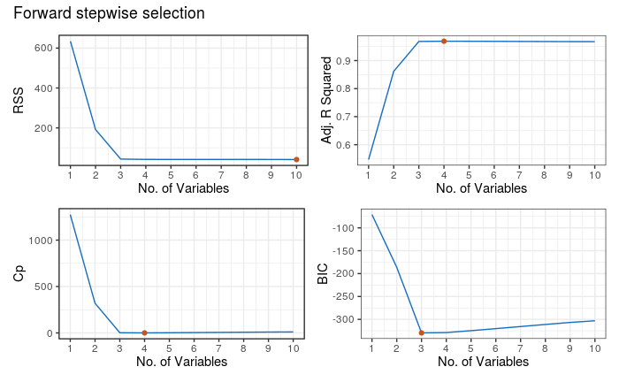

```r
p <- length(forward_summary$rss)
summary <- data.frame(
  p = 1:p,
  rss = forward_summary$rss,
  adjr2 = forward_summary$adjr2,
  cp = forward_summary$cp,
  bic = forward_summary$bic)

p1 <- summary %>%
  ggplot(aes(p, rss)) +
  geom_line(color = ISLR_blue) +
  geom_point(data = summary[which.min(summary$rss), ],
             color = ISLR_orange) +
  scale_x_continuous(breaks = 1:10) +
  labs(x = "No. of Variables", y = "RSS")

p2 <- summary %>%
  ggplot(aes(p, adjr2)) +
  geom_line(color = ISLR_blue) +
  geom_point(data = summary[which.max(summary$adjr2), ],
             color = ISLR_orange) +
  scale_x_continuous(breaks = 1:10) +
  labs(x = "No. of Variables", y = "Adj. R Squared")

p3 <- summary %>%
  ggplot(aes(p, cp)) +
  geom_line(color = ISLR_blue) +
  geom_point(data = summary[which.min(summary$cp), ],
             color = ISLR_orange) +
  scale_x_continuous(breaks = 1:10) +
  labs(x = "No. of Variables", y = "Cp")

p4 <- summary %>%
  ggplot(aes(p, bic)) +
  geom_line(color = ISLR_blue) +
  geom_point(data = summary[which.min(summary$bic), ],
             color = ISLR_orange) +
  scale_x_continuous(breaks = 1:10) +
  labs(x = "No. of Variables", y = "BIC")

(p1 + p2) / (p3 + p4) + plot_annotation(title = "Forward stepwise selection")
```

#### $C_p$

The model with the lowest $C_p$:

```r
str_interp("No. of variables: ${which.min(forward_summary$cp)}")
```

```
[1] "No. of variables: 4"
```

```r
coef(forward, id = which.min(forward_summary$cp)) %>% round(3)
```

```
(Intercept)         x.1         x.2         x.3         x.5
      1.050       1.771      -2.108       0.491       0.057
```

True coefficients:

```r
beta
```

```
 Int  x^1  x^2  x^3
 1.0  1.5 -2.0  0.8
```

#### BIC

The model with the lowest BIC:

```r
str_interp("No. of variables: ${which.min(forward_summary$bic)}")
```

```
[1] "No. of variables: 3"
```

```r
coef(forward, id = which.min(forward_summary$bic)) %>% round(3)
```

```
(Intercept)         x.1         x.2         x.3
      1.043       1.483      -2.087       0.812
```

True coefficients:

```r
beta
```

```
 Int  x^1  x^2  x^3
 1.0  1.5 -2.0  0.8
```

#### Adjusted R Squared

The model with the best Adjusted R Squared:

```r
str_interp("No. of variables: ${which.max(forward_summary$adjr2)}")
```

```
[1] "No. of variables: 4"
```

```r
coef(forward, id = which.max(forward_summary$adjr2)) %>% round(3)
```

```
(Intercept)         x.1         x.2         x.3         x.5
      1.050       1.771      -2.108       0.491       0.057
```

True coefficients:

```r
beta
```

```
 Int  x^1  x^2  x^3
 1.0  1.5 -2.0  0.8
```

### Backward Stepwise Selection

```r
backward <- regsubsets(y ~ ., data, method = "backward", nvmax = 10)
backward_summary <- summary(backward)
backward_summary
```

```
Subset selection object
Call: regsubsets.formula(y ~ ., data, method = "backward", nvmax = 10)
10 Variables  (and intercept)
     Forced in Forced out
x.1      FALSE      FALSE
x.2      FALSE      FALSE
x.3      FALSE      FALSE
x.4      FALSE      FALSE
x.5      FALSE      FALSE
x.6      FALSE      FALSE
x.7      FALSE      FALSE
x.8      FALSE      FALSE
x.9      FALSE      FALSE
x.10     FALSE      FALSE
1 subsets of each size up to 10
Selection Algorithm: backward
          x.1 x.2 x.3 x.4 x.5 x.6 x.7 x.8 x.9 x.10
1  ( 1 )  "*" " " " " " " " " " " " " " " " " " "
2  ( 1 )  "*" "*" " " " " " " " " " " " " " " " "
3  ( 1 )  "*" "*" " " " " "*" " " " " " " " " " "
4  ( 1 )  "*" "*" " " " " "*" " " "*" " " " " " "
5  ( 1 )  "*" "*" " " " " "*" " " "*" " " "*" " "
6  ( 1 )  "*" "*" " " " " "*" " " "*" "*" "*" " "
7  ( 1 )  "*" "*" " " " " "*" " " "*" "*" "*" "*"
8  ( 1 )  "*" "*" " " " " "*" "*" "*" "*" "*" "*"
9  ( 1 )  "*" "*" " " "*" "*" "*" "*" "*" "*" "*"
10  ( 1 ) "*" "*" "*" "*" "*" "*" "*" "*" "*" "*"
```

Plot the error metrics:

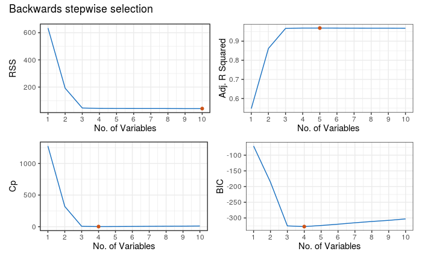

```r
p <- length(backward_summary$rss)
summary <- data.frame(
  p = 1:p,
  rss = backward_summary$rss,
  adjr2 = backward_summary$adjr2,
  cp = backward_summary$cp,
  bic = backward_summary$bic)

p1 <- summary %>%
  ggplot(aes(p, rss)) +
  geom_line(color = ISLR_blue) +
  geom_point(data = summary[which.min(summary$rss), ],
             color = ISLR_orange) +
  scale_x_continuous(breaks = 1:10) +
  labs(x = "No. of Variables", y = "RSS")

p2 <- summary %>%
  ggplot(aes(p, adjr2)) +
  geom_line(color = ISLR_blue) +
  geom_point(data = summary[which.max(summary$adjr2), ],
             color = ISLR_orange) +
  scale_x_continuous(breaks = 1:10) +
  labs(x = "No. of Variables", y = "Adj. R Squared")

p3 <- summary %>%
  ggplot(aes(p, cp)) +
  geom_line(color = ISLR_blue) +
  geom_point(data = summary[which.min(summary$cp), ],
             color = ISLR_orange) +
  scale_x_continuous(breaks = 1:10) +
  labs(x = "No. of Variables", y = "Cp")

p4 <- summary %>%
  ggplot(aes(p, bic)) +
  geom_line(color = ISLR_blue) +
  geom_point(data = summary[which.min(summary$bic), ],
             color = ISLR_orange) +
  scale_x_continuous(breaks = 1:10) +
  labs(x = "No. of Variables", y = "BIC")

(p1 + p2) / (p3 + p4) + plot_annotation(title = "Backwards stepwise selection")
```

#### $C_p$

The model with the lowest $C_p$:

```r
str_interp("No. of variables: ${which.min(backward_summary$cp)}")
```

```
[1] "No. of variables: 4"
```

```r
coef(backward, id = which.min(backward_summary$cp)) %>% round(3)
```

```
(Intercept)         x.1         x.2         x.5         x.7
      1.040       2.048      -2.092       0.252      -0.021
```

True coefficients:

```r
beta
```

```
 Int  x^1  x^2  x^3
 1.0  1.5 -2.0  0.8
```

#### BIC

The model with the lowest BIC:

```r
str_interp("No. of variables: ${which.min(backward_summary$bic)}")
```

```
[1] "No. of variables: 4"
```

```r
coef(backward, id = which.min(backward_summary$bic)) %>% round(3)
```

```
(Intercept)         x.1         x.2         x.5         x.7
      1.040       2.048      -2.092       0.252      -0.021
```

True coefficients:

```r
beta
```

```
 Int  x^1  x^2  x^3
 1.0  1.5 -2.0  0.8
```

#### Adjusted R Squared

The model with the best Adjusted R Squared:

```r
str_interp("No. of variables: ${which.max(backward_summary$adjr2)}")
```

```
[1] "No. of variables: 5"
```

```r
coef(backward, id = which.max(backward_summary$adjr2)) %>% round(3)
```

```
(Intercept)         x.1         x.2         x.5         x.7         x.9
      1.051       1.948      -2.109       0.394      -0.082       0.007
```

True coefficients:

```r
beta
```

```
 Int  x^1  x^2  x^3
 1.0  1.5 -2.0  0.8
```

### Summary

#### $C_p$

No. of variables:

```r
str_interp("No. of variables - Best Subset Selection: ${which.min(best_summary$cp)}")
```

```
[1] "No. of variables - Best Subset Selection: 4"
```

```r
str_interp("No. of variables - Forward Stepwise Selection: ${which.min(forward_summary$cp)}")
```

```
[1] "No. of variables - Forward Stepwise Selection: 4"
```

```r
str_interp("No. of variables - Backward Stepwise Selection: ${which.min(backward_summary$cp)}")
```

```
[1] "No. of variables - Backward Stepwise Selection: 4"
```

Coefficients:

```r
coef(best, id = which.min(best_summary$cp)) %>% round(3)
```

```
(Intercept)         x.1         x.2         x.3         x.5
      1.050       1.771      -2.108       0.491       0.057
```

```r
coef(forward, id = which.min(forward_summary$cp)) %>% round(3)
```

```
(Intercept)         x.1         x.2         x.3         x.5
      1.050       1.771      -2.108       0.491       0.057
```

```r
coef(backward, id = which.min(backward_summary$cp)) %>% round(3)
```

```
(Intercept)         x.1         x.2         x.5         x.7
      1.040       2.048      -2.092       0.252      -0.021
```

#### BIC

No. of variables:

```r
str_interp("No. of variables - Best Subset Selection: ${which.min(best_summary$bic)}")
```

```
[1] "No. of variables - Best Subset Selection: 3"
```

```r
str_interp("No. of variables - Forward Stepwise Selection: ${which.min(forward_summary$bic)}")
```

```
[1] "No. of variables - Forward Stepwise Selection: 3"
```

```r
str_interp("No. of variables - Backward Stepwise Selection: ${which.min(backward_summary$bic)}")
```

```
[1] "No. of variables - Backward Stepwise Selection: 4"
```

Coefficients:

```r
coef(best, id = which.min(best_summary$bic)) %>% round(3)
```

```
(Intercept)         x.1         x.2         x.3
      1.043       1.483      -2.087       0.812
```

```r
coef(forward, id = which.min(forward_summary$bic)) %>% round(3)
```

```
(Intercept)         x.1         x.2         x.3
      1.043       1.483      -2.087       0.812
```

```r
coef(backward, id = which.min(backward_summary$bic)) %>% round(3)
```

```
(Intercept)         x.1         x.2         x.5         x.7
      1.040       2.048      -2.092       0.252      -0.021
```

#### Adjusted R Squared

No. of variables:

```r
str_interp("No. of variables - best Subset Selection: ${which.max(best_summary$adjr2)}")
```

```
[1] "No. of variables - best Subset Selection: 4"
```

```r
str_interp("No. of variables - Forward Stepwise Selection: ${which.max(forward_summary$adjr2)}")
```

```
[1] "No. of variables - Forward Stepwise Selection: 4"
```

```r
str_interp("No. of variables - Backward Stepwise Selection: ${which.max(backward_summary$adjr2)}")
```

```
[1] "No. of variables - Backward Stepwise Selection: 5"
```

Coefficients:

```r
coef(best, id = which.max(best_summary$adjr2)) %>% round(3)
```

```
(Intercept)         x.1         x.2         x.3         x.5
      1.050       1.771      -2.108       0.491       0.057
```

```r
coef(forward, id = which.max(forward_summary$adjr2)) %>% round(3)
```

```
(Intercept)         x.1         x.2         x.3         x.5
      1.050       1.771      -2.108       0.491       0.057
```

```r
coef(backward, id = which.max(backward_summary$adjr2)) %>% round(3)
```

```
(Intercept)         x.1         x.2         x.5         x.7         x.9
      1.051       1.948      -2.109       0.394      -0.082       0.007
```

### (e)

```r
# Create a model.matrix for use in glmnet()
X.mod <- model.matrix(y ~. , data[, -11])[, -1]

# Generate a grid of lambda values:
grid <- 10^seq(10, -2, length=100)
```

Generate a Lasso model on the training data and plot the result:

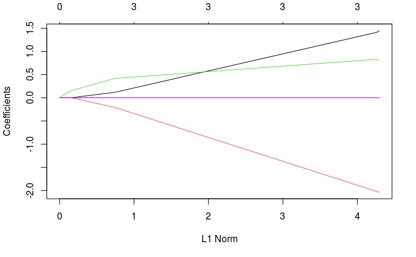

```r
set.seed(1)
train <- sample(1:n, n/2)
test <- (-train)

library(glmnet)
lasso <- glmnet(X.mod[train, ], y[train], alpha = 1, lambda = grid)
plot(lasso)
```

True coefficients:

```r
beta
```

```
 Int  x^1  x^2  x^3
 1.0  1.5 -2.0  0.8
```

Plot the cross-validation error as a function of $\lambda$:

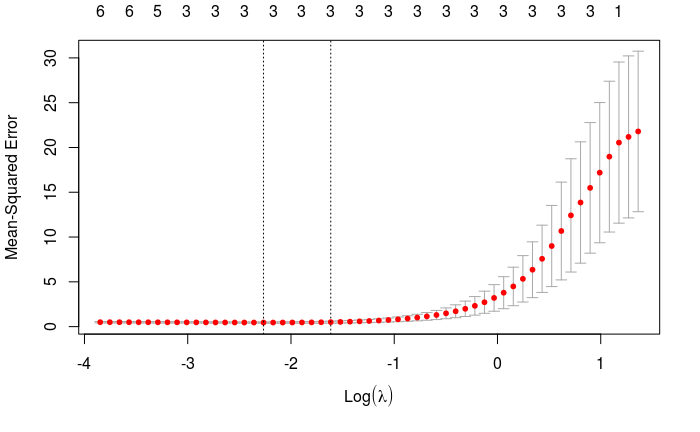

```r
set.seed(1)
# Perform CV using ONLY the training data as per ISLR pg 248
cv.out <- cv.glmnet(X.mod[train, ], y[train], alpha=1)
plot(cv.out)
```

Use cross-validation to choose the optimal $\lambda$:

```r
bestlam = cv.out$lambda.min
bestlam
```

```
[1] 0.1037477
```

MSE of the model using the optimal value for $\lambda$:

```r
lasso_pred <- predict(lasso, s = bestlam, newx = X.mod[test, ])
mean((lasso_pred - y[test])^2)
```

```
[1] 0.5465796
```

Generate a lasso model on all of the data, then report the coefficients of the best model as obtained by cross-validation:

```r
out <- glmnet(X.mod, y, alpha = 1, lambda = grid)
lasso_coef <- predict(out, type = "coefficients", s = bestlam)[1:11, ]
round(lasso_coef, 3)
```

```
(Intercept)         x.1         x.2         x.3         x.4         x.5         x.6         x.7         x.8         x.9
      0.965       1.521      -1.979       0.684       0.000       0.016       0.000       0.000       0.000       0.000
       x.10
      0.000
```

```r
beta
```

```
 Int  x^1  x^2  x^3
 1.0  1.5 -2.0  0.8
```

### (f)

```r
beta7 = 0.7
y <- beta0 + beta7*x^7 + eps
data <- data.frame(X, y)
```

#### Best Subset Selection

Use best subset selection with cross-validation to obtain the best model:

```r
k <- 10
set.seed(1)
folds <- sample(1:k, nrow(data), replace = TRUE)
cv.errors <- matrix(NA, k, 10, dimnames = list(NULL, paste(1:10)))

predict.regsubsets <- function(object, newdata, id,...) {
  form <- as.formula(object$call[[2]])
  mat <- model.matrix(form, newdata)
  coefi <- coef(object, id=id)
  xvars <- names(coefi)
  mat[, xvars]%*%coefi
}

for(j in 1:k) {
  best <- regsubsets(y ~ ., data = data[folds!=j, ], nvmax=10)
  for(i in 1:10) {
    pred <- predict(best, data[folds == j, ], id = i)
    cv.errors[j, i] <- mean((y[folds == j] - pred)^2)
  }
}

mean.cv.errors <- apply(cv.errors, 2, mean)
mean.cv.errors
```

```
        1         2         3         4         5         6         7         8         9        10
0.4619206 0.4715240 0.4734637 0.4866210 0.5026161 1.0544480 0.6652165 0.5406451 0.8449384 1.8906532
```

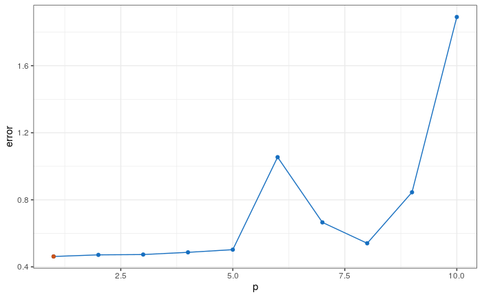

```r
data.frame(
  p = 1:p,
  error = mean.cv.errors
) %>%
  ggplot(aes(p, error)) +
  geom_point(color = ISLR_blue) +
  geom_line(color = ISLR_blue) +
  geom_point(data = tibble(p = which.min(mean.cv.errors), error = mean.cv.errors[p]),
             color = ISLR_orange)
```

The best subset selection method has chosen the 1-variable model. Perform best subset selection on the whole data set and obtain the coefficients for the 1-variable model:

```r
best <- regsubsets(y ~ ., data = data, nvmax=10)
round(coef(best, 1), 3)
```

```
(Intercept)         x.7
      0.971       0.701
```

We see that the best subset selection has returned a 1-variable model with the `x^7` variable, and its coefficient is very close to the true value of $\beta_7 = 0.7$.

#### Lasso

Generate a lasso model on the training data and inspect the plot:

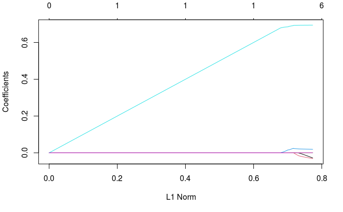

```r
lasso <- glmnet(X.mod[train, ], y[train], alpha = 1, lambda = grid)
plot(lasso)
```

Use cross-validation to choose the optimal $\lambda$:

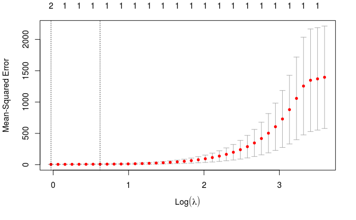

```r
set.seed(1)
cv.out <- cv.glmnet(X.mod[train, ], y[train], alpha = 1)
plot(cv.out)
```

```r
bestlam = cv.out$lambda.min
bestlam
```

```
[1] 0.9712578
```

```r
lasso_pred <- predict(lasso, s = bestlam, newx = X.mod[test, ])
mean((lasso_pred - y[test])^2)
```

```
[1] 2.022436
```

Generate a lasso model on all of the data, then report the coefficients of the best model as obtained by cross-validation:

```r
out <- glmnet(X.mod, y, alpha = 1, lambda = grid)
lasso_coef <- predict(out, type = "coefficients", s = bestlam)[1:11, ]
round(lasso_coef, 3)
```

```
(Intercept)         x.1         x.2         x.3         x.4         x.5         x.6         x.7         x.8         x.9
      1.039       0.000       0.000       0.000       0.000       0.000       0.000       0.684       0.000       0.000
       x.10
      0.000
```

The final lasso model also has only one variable, `x^7`, and its coefficient is very close to the true value of $\beta_7 = 0.7$.

## Exercise 9

### (a)

Split the data set into a training set and a test set:

```r
set.seed(1)
n <- nrow(College)
train <- sample(n, 5*n/7)
test = -(train)
MSE = c()
```

### (b)

Fit a linear model using least squares on the training set, and report the test error obtained:

```r
lm_fit <- lm(Apps ~ ., data = College[train, ])
summary(lm_fit)
```

```
Call:
lm(formula = Apps ~ ., data = College[train, ])

Residuals:
    Min      1Q  Median      3Q     Max
-5755.4  -449.2    -5.3   335.6  7424.9

Coefficients:
              Estimate Std. Error t value Pr(>|t|)
(Intercept) -6.252e+02  4.868e+02  -1.284  0.19960
PrivateYes  -5.255e+02  1.624e+02  -3.237  0.00128 **
Accept       1.705e+00  4.645e-02  36.702  < 2e-16 ***
Enroll      -1.013e+00  2.394e-01  -4.234 2.70e-05 ***
Top10perc    5.410e+01  6.344e+00   8.529  < 2e-16 ***
Top25perc   -1.616e+01  5.023e+00  -3.217  0.00137 **
F.Undergrad  3.066e-02  4.338e-02   0.707  0.48001
P.Undergrad  6.822e-02  3.619e-02   1.885  0.05993 .
Outstate    -8.415e-02  2.134e-02  -3.944 9.07e-05 ***
Room.Board   1.669e-01  5.536e-02   3.015  0.00269 **
Books        2.766e-01  2.679e-01   1.032  0.30239
Personal     9.315e-04  7.028e-02   0.013  0.98943
PhD         -1.034e+01  5.323e+00  -1.942  0.05270 .
Terminal     4.160e-01  5.941e+00   0.070  0.94421
S.F.Ratio    1.847e+01  1.578e+01   1.170  0.24236
perc.alumni  2.229e+00  4.748e+00   0.469  0.63898
Expend       5.711e-02  1.316e-02   4.338 1.71e-05 ***
Grad.Rate    7.119e+00  3.441e+00   2.069  0.03903 *
---
Signif. codes:  0 ‘***’ 0.001 ‘**’ 0.01 ‘*’ 0.05 ‘.’ 0.1 ‘ ’ 1

Residual standard error: 1018 on 537 degrees of freedom
Multiple R-squared:  0.9326,    Adjusted R-squared:  0.9305
F-statistic: 437.1 on 17 and 537 DF,  p-value: < 2.2e-16
```

Test error (MSE):

```r
lm_pred <- predict(lm_fit, College[test, ])
lm_test_error <- mean((lm_pred - College$Apps[test])^2)
MSE = c(MSE, lm = lm_test_error)
lm_test_error
```

```
[1] 1288114
```

### (c)

Fit a ridge regression model on the training set, with $\lambda$ chosen by cross-validation. Report the test error obtained.

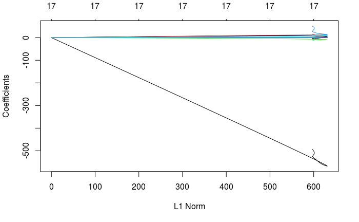

```r
X <- model.matrix(Apps ~. , College)[, -1]
y <- College$Apps

grid <- 10^seq(10, -2, length = 100)
ridge <- glmnet(X, y, alpha = 0, lambda = grid, thresh = 1e-12)
plot(ridge)
```

Choose $\lambda$ using CV:

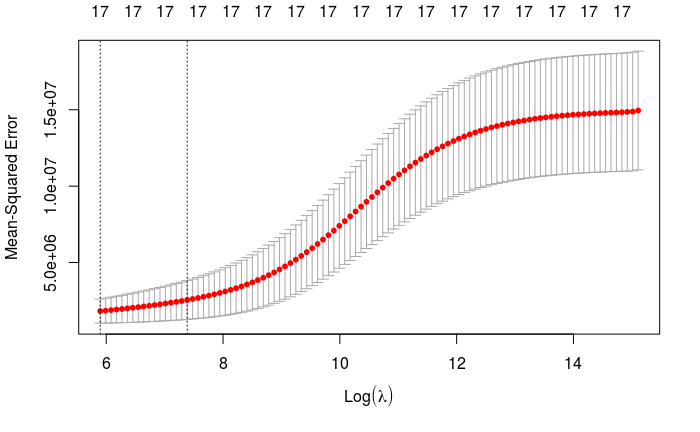

```r
set.seed(1)
cv.out <- cv.glmnet(X[train, ], y[train], alpha = 0)
plot(cv.out)
```

```r
bestlam <- cv.out$lambda.min
bestlam
```

```
[1] 364.1882
```

Test error (MSE):

```r
ridge_test_error <- mean((predict(ridge, s = bestlam, newx = X[test, ]) - y[test])^2)
MSE = c(MSE, ridge = ridge_test_error)
ridge_test_error
```

```
[1] 1105739
```

### (d)

Fit a lasso model on the training set, with λ chosen by cross-validation. Report the test error obtained, along with the number of non-zero coefficient estimates:

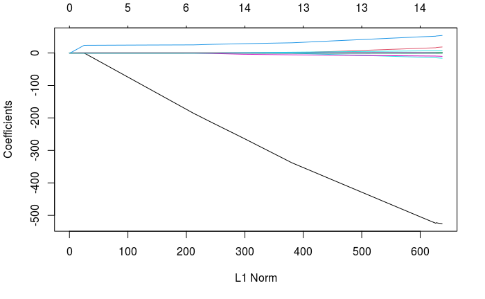

```r
lasso <- glmnet(X[train, ], y[train], alpha = 1, lambda = grid)
plot(lasso)
```

Choose $\lambda$ using CV:

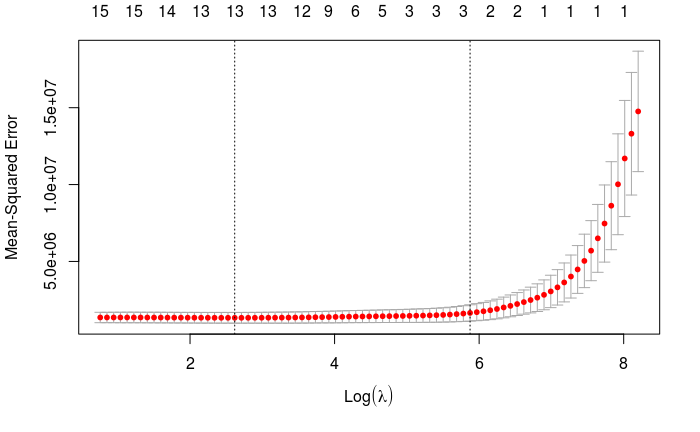

```r
set.seed(1)
cv.out <- cv.glmnet(X[train, ], y[train], alpha=1)
plot(cv.out)
```

```r
bestlam = cv.out$lambda.min
bestlam
```

```
[1] 13.71145
```

Test error (MSE):

```r
lasso_test_error <- mean((predict(lasso, s = bestlam, newx = X[test, ])- y[test])^2)
MSE = c(MSE, lasso = lasso_test_error)
lasso_test_error
```

```
[1] 1253310
```

Generate a lasso model on all of the data, then report the coefficients of the best model as obtained by cross-validation:

```r
out <- glmnet(X, y, alpha = 1, lambda = grid)
lasso_coef <- predict(out, type = "coefficients", s = bestlam)[1:18, ]
round(lasso_coef, 3)
```

```
(Intercept)  PrivateYes      Accept      Enroll   Top10perc   Top25perc F.Undergrad P.Undergrad    Outstate  Room.Board
   -550.682    -461.081       1.503      -0.353      39.464      -6.436       0.000       0.035      -0.069       0.135
      Books    Personal         PhD    Terminal   S.F.Ratio perc.alumni      Expend   Grad.Rate
      0.000       0.013      -6.773      -3.147       8.772      -0.684       0.073       6.354
```

Number of non-zero coefficients:

```r
lasso_coef[abs(lasso_coef) > 0] %>% length()
```

```
[1] 16
```

```r
lasso_coef[abs(lasso_coef) > 0] %>% names()
```

```
 [1] "(Intercept)" "PrivateYes"  "Accept"      "Enroll"      "Top10perc"   "Top25perc"   "P.Undergrad" "Outstate"
 [9] "Room.Board"  "Personal"    "PhD"         "Terminal"    "S.F.Ratio"   "perc.alumni" "Expend"      "Grad.Rate"
```

### (e)

Fit a PCR model on the training set, with $M$ chosen by cross-validation. Report the test error obtained, along with the value of $M$ selected by cross-validation.

```r
set.seed(1)
pcr_fit <- pcr(Apps ~ ., data = College, subset = train, scale = TRUE, validation = "CV")
summary(pcr_fit)
```

```
Data:   X dimension: 555 17
    Y dimension: 555 1
Fit method: svdpc
Number of components considered: 17

VALIDATION: RMSEP
Cross-validated using 10 random segments.
       (Intercept)  1 comps  2 comps  3 comps  4 comps  5 comps  6 comps  7 comps  8 comps  9 comps  10 comps  11 comps
CV            3862     3774     2102     2103     1752     1697     1685     1685     1630     1607      1612      1621
adjCV         3862     3773     2099     2102     1740     1687     1679     1680     1620     1601      1605      1614
       12 comps  13 comps  14 comps  15 comps  16 comps  17 comps
CV         1627      1628      1627      1559      1197      1156
adjCV      1621      1622      1621      1539      1186      1147

TRAINING: % variance explained
      1 comps  2 comps  3 comps  4 comps  5 comps  6 comps  7 comps  8 comps  9 comps  10 comps  11 comps  12 comps  13 comps
X      32.102    57.00    64.31    70.19    75.52     80.5    84.29    87.63    90.60     92.83     94.91     96.73     97.82
Apps    5.263    71.25    71.27    80.63    82.53     82.6    82.68    84.03    84.51     84.75     84.79     84.79     84.93
      14 comps  15 comps  16 comps  17 comps
X        98.70     99.38     99.85    100.00
Apps     84.99     90.01     92.99     93.26
```

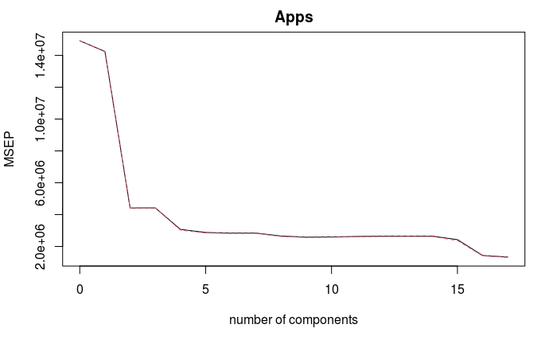

```r
validationplot(pcr_fit, val.type = "MSEP")
```

In the above plot, the MSE decrease as $M$ increases. We will choose $M=9$ components, as this captures 90.60% of the variance in the predictors, while being equal to $p/2$ (i.e. the dimension is reduced by half).

```r
pcr_pred <- predict(pcr_fit, College[test, ], ncomp = 9)
pcr_test_error <- mean((pcr_pred - College$Apps[test])^2)
MSE = c(MSE, pcr = pcr_test_error)
pcr_test_error
```

```
[1] 1767911
```

### (f)

Fit a PLS model on the training set, with $M$ chosen by cross-validation. Report the test error obtained, along with the value of $M$ selected by cross-validation.

```r
set.seed(1)
pls_fit <- plsr(Apps ~ ., data = College, subset = train, scale = TRUE, validation = "CV")
summary(pls_fit)
```

```
Data:   X dimension: 555 17
    Y dimension: 555 1
Fit method: kernelpls
Number of components considered: 17

VALIDATION: RMSEP
Cross-validated using 10 random segments.
       (Intercept)  1 comps  2 comps  3 comps  4 comps  5 comps  6 comps  7 comps  8 comps  9 comps  10 comps  11 comps
CV            3862     1939     1737     1529     1463     1239     1200     1180     1168     1163      1163      1159
adjCV         3862     1934     1734     1521     1440     1219     1188     1170     1159     1153      1153      1150
       12 comps  13 comps  14 comps  15 comps  16 comps  17 comps
CV         1158      1157      1156      1156      1156      1156
adjCV      1149      1148      1147      1147      1147      1147

TRAINING: % variance explained
      1 comps  2 comps  3 comps  4 comps  5 comps  6 comps  7 comps  8 comps  9 comps  10 comps  11 comps  12 comps  13 comps
X       25.57    46.92    62.48    64.92    67.54    72.52    77.25    80.78    82.65     85.66     88.38     90.97     93.15
Apps    76.39    82.41    86.91    90.76    92.75    93.00    93.08    93.15    93.20     93.22     93.24     93.25     93.26
      14 comps  15 comps  16 comps  17 comps
X        95.19     97.04     98.26    100.00
Apps     93.26     93.26     93.26     93.26
```

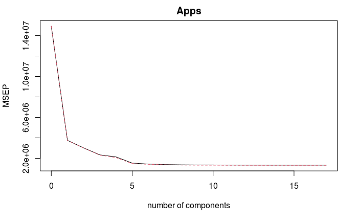

```r
validationplot(pls_fit, val.type="MSEP")
```

The graph suggests $M=6$ will give a minimal MSE. Find the test MSE with 6 components:

```r
pls_pred <- predict(pls_fit, College[test, ], ncomp=6)
pls_test_error <- mean((pls_pred - College$Apps[test])^2)
MSE = c(MSE, pls=pls_test_error)
pls_test_error
```

```
[1] 1308453
```

### (g)

Based on test MSE, ridge regression was the best with PCR performing worst:

```r
sort(MSE)
```

```
  ridge   lasso      lm     pls     pcr
1105739 1253310 1288114 1308453 1767911
```

We can also calculate the test R^2:

```r
test_avg <- mean(College$Apps[test])
lm_test_r2 <- 1 - lm_test_error / mean((test_avg - College$Apps[test])^2)
ridge_test_r2 <- 1 - ridge_test_error / mean((test_avg - College$Apps[test])^2)
lasso_test_r2 <- 1 - lasso_test_error / mean((test_avg - College$Apps[test])^2)
pcr_test_r2 <- 1 - pcr_test_error / mean((test_avg - College$Apps[test])^2)
pls_test_r2 <- 1 - pls_test_error / mean((test_avg - College$Apps[test])^2)
test_r2 <- c(lm = lm_test_r2, ridge = ridge_test_r2, lasso = lasso_test_r2, pcr = pcr_test_r2, pls = pls_test_r2)
sort(test_r2, decreasing = TRUE)
```

```
    ridge     lasso        lm       pls       pcr
0.9271378 0.9174137 0.9151203 0.9137800 0.8835042
```

## Exercise 10

### (a)

Generate a data set with p = 20 features, n = 1,000 observations, and an associated quantitative response vector generated according to the model
$$Y = X\beta + \epsilon.$$
where $\beta$ has some elements that are exactly equal to zero.

```r
n <-  1000
p <-  20
eps <- rnorm(1000, sd = 0.7)

# Generate the X data:
set.seed(2)
x <- rnorm(n, mean = sample(1:100, 1), sd = sample(0:50, 1))
X <- x
for(i in 2:p) {
  x_i <- rnorm(n, mean = sample(1:100, 1), sd = sample(0:50, 1))
  X <- cbind(X, x_i)
}
colnames(X) <- paste0("x.", 1:p)

beta = round(runif(20, -5, 5), 1)
beta[c(3, 8, 15)] = 0 # set some beta's to zero

y <- X%*%beta + eps

data <- data.frame(X, y)
```

### (b)

Split the data set into a training set containing 100 observations and a test set containing 900 observations:

```r
train <- sample(n, n/10) # 100 obs.
test <- (-train) # 900 obs.
```

### (c)

Perform best subset selection on the training set, and plot the training set MSE associated with the best model of each size.

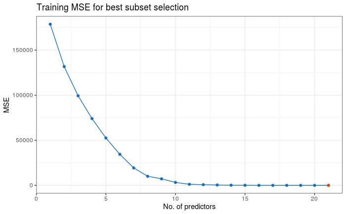

```r
regfit.train <- regsubsets(y ~ ., data[train, ], nvmax = 20)

training.errors <- rep(0, p + 1)
training.errors[1] <- mean((y[train] - mean(y[train]))^2) # null model (intercept only) ???
for(i in 1:p) {
  pred <- predict.regsubsets(regfit.train, data[train, ], id = i)
  training.errors[i + 1] = mean((pred - y[train])^2)
}

data.frame(
  p = 1:(p+1),
  error = training.errors
) %>%
  ggplot(aes(p, error)) +
  geom_point(color = ISLR_blue) +
  geom_line(color = ISLR_blue) +
  geom_point(data = tibble(p = which.min(training.errors), error = training.errors[p]),
             color = ISLR_orange) +
  labs(x = "No. of predictors", y = "MSE", title = "Training MSE for best subset selection")
```

### (d)

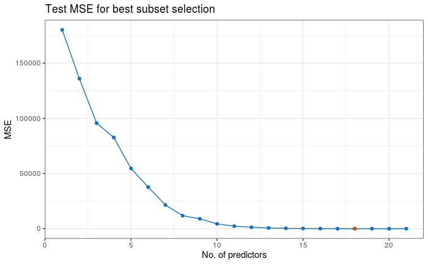

```r
test.errors <- rep(0, p+1)
test.errors[1] <- mean((y[test] - mean(y[train]))^2) # null model (intercept only) ???
for(i in 1:p) {
  pred <- predict.regsubsets(regfit.train, data[test, ], id=i)
  test.errors[i+1] = mean((pred - y[test])^2)
}

tibble(
  p = 1:(p+1),
  error = test.errors
) %>%
  ggplot(aes(p, error)) +
  geom_point(color = ISLR_blue) +
  geom_line(color = ISLR_blue) +
  geom_point(data = tibble(p = which.min(test.errors), error = test.errors[p]),
             color = ISLR_orange) +
  labs(x = "No. of predictors", y = "MSE", title = "Test MSE for best subset selection")
```

### (e)

Find which model has the lowest test error:

```r
which.min(test.errors)
```

```
[1] 18
```

We see that the 18-variable model has the lowest test error. This means that only two variables were excluded to obtain the optimal model, even though 3 of the variables have a $\beta$-coefficient of zero.

The variables and coefficients of the 18-variable model are:

```r
round(coef(regfit.train, 18), 3)
```

```
(Intercept)         x.1         x.2         x.3         x.4         x.5         x.6         x.7         x.9        x.10
     -8.194      -3.192      -4.306       0.008       2.406      -1.105       4.301      -4.430       0.203       3.402
       x.11        x.12        x.13        x.14        x.16        x.17        x.18        x.19        x.20
      4.799      -1.501       0.603       4.709       3.298       3.399      -4.099      -2.010       2.682
```

The true model includes 17 variables; inspect the variables and coefficients of the 17-variable model to see how they compare to the true model:

```r
round(coef(regfit.train, 17), 3)
```

```
(Intercept)         x.1         x.2         x.4         x.5         x.6         x.7         x.9        x.10        x.11
     -7.570      -3.192      -4.306       2.406      -1.105       4.301      -4.426       0.201       3.402       4.799
       x.12        x.13        x.14        x.16        x.17        x.18        x.19        x.20
     -1.501       0.603       4.710       3.298       3.400      -4.100      -2.008       2.676
```

We see that the model has correctly excluded `x.3`, `x.8` and `x.15`, meaning that this model more closely captures the true model, but the test error is slightly higher than the 18-variable model.

Compare the coefficients of the 17-variable model to the true coefficients:

```r
as.numeric(round(coef(regfit.train, 17)[-1], 1))
```

```
 [1] -3.2 -4.3  2.4 -1.1  4.3 -4.4  0.2  3.4  4.8 -1.5  0.6  4.7  3.3  3.4 -4.1 -2.0  2.7
```

```r
beta[which(beta!=0)]
```

```
 [1] -3.2 -4.3  2.4 -1.1  4.3 -4.4  0.2  3.4  4.8 -1.5  0.6  4.7  3.3  3.4 -4.1 -2.0  2.6
```

Compare the test R^2 of the 17- and 18-variable models:

```r
test.avg <- mean(y[test])
test.r2.17 <- 1 - test.errors[17] / mean((test.avg - y[test])^2)
test.r2.18 <- 1 - test.errors[18] / mean((test.avg - y[test])^2)
c(mod.17 = test.r2.17, mod.18 = test.r2.18)
```

```
   mod.17    mod.18
0.9999611 0.9999966
```

As we can see both R^2 values are extremely high, indicating that both models perform very well, with the 17-variable model matching almost exactly with the true model.

Below is a summary of all of the variables included in each model. Many of the models with fewer variables have correctly excluded `x.3`, `x.8` and `x.15`.

```r
summary(regfit.train)$outmat
```

```
          x.1 x.2 x.3 x.4 x.5 x.6 x.7 x.8 x.9 x.10 x.11 x.12 x.13 x.14 x.15 x.16 x.17 x.18 x.19 x.20
1  ( 1 )  " " " " " " " " " " "*" " " " " " " " "  " "  " "  " "  " "  " "  " "  " "  " "  " "  " "
2  ( 1 )  " " " " " " " " " " "*" " " " " " " " "  "*"  " "  " "  " "  " "  " "  " "  " "  " "  " "
3  ( 1 )  " " " " " " " " " " "*" " " " " " " " "  "*"  " "  " "  " "  " "  " "  "*"  " "  " "  " "
4  ( 1 )  " " " " " " " " " " "*" " " " " " " "*"  "*"  " "  " "  " "  " "  " "  "*"  " "  " "  " "
5  ( 1 )  " " " " " " " " " " "*" " " " " " " "*"  "*"  " "  " "  " "  " "  "*"  "*"  " "  " "  " "
6  ( 1 )  " " " " " " " " " " "*" " " " " " " "*"  "*"  " "  " "  " "  " "  "*"  "*"  "*"  " "  " "
7  ( 1 )  " " "*" " " " " " " "*" " " " " " " "*"  "*"  " "  " "  " "  " "  "*"  "*"  "*"  " "  " "
8  ( 1 )  "*" "*" " " " " " " "*" " " " " " " "*"  "*"  " "  " "  " "  " "  "*"  "*"  "*"  " "  " "
9  ( 1 )  "*" "*" " " " " " " "*" " " " " " " "*"  "*"  "*"  " "  " "  " "  "*"  "*"  "*"  " "  " "
10  ( 1 ) "*" "*" " " " " " " "*" " " " " " " "*"  "*"  "*"  " "  "*"  " "  "*"  "*"  "*"  " "  " "
11  ( 1 ) "*" "*" " " " " "*" "*" " " " " " " "*"  "*"  "*"  " "  "*"  " "  "*"  "*"  "*"  " "  " "
12  ( 1 ) "*" "*" " " " " "*" "*" "*" " " " " "*"  "*"  "*"  " "  "*"  " "  "*"  "*"  "*"  " "  " "
13  ( 1 ) "*" "*" " " "*" "*" "*" "*" " " " " "*"  "*"  "*"  " "  "*"  " "  "*"  "*"  "*"  " "  " "
14  ( 1 ) "*" "*" " " "*" "*" "*" "*" " " " " "*"  "*"  "*"  " "  "*"  " "  "*"  "*"  "*"  "*"  " "
15  ( 1 ) "*" "*" " " "*" "*" "*" "*" " " " " "*"  "*"  "*"  "*"  "*"  " "  "*"  "*"  "*"  "*"  " "
16  ( 1 ) "*" "*" " " "*" "*" "*" "*" " " " " "*"  "*"  "*"  "*"  "*"  " "  "*"  "*"  "*"  "*"  "*"
17  ( 1 ) "*" "*" " " "*" "*" "*" "*" " " "*" "*"  "*"  "*"  "*"  "*"  " "  "*"  "*"  "*"  "*"  "*"
18  ( 1 ) "*" "*" "*" "*" "*" "*" "*" " " "*" "*"  "*"  "*"  "*"  "*"  " "  "*"  "*"  "*"  "*"  "*"
19  ( 1 ) "*" "*" "*" "*" "*" "*" "*" " " "*" "*"  "*"  "*"  "*"  "*"  "*"  "*"  "*"  "*"  "*"  "*"
20  ( 1 ) "*" "*" "*" "*" "*" "*" "*" "*" "*" "*"  "*"  "*"  "*"  "*"  "*"  "*"  "*"  "*"  "*"  "*"
```

Change the data to see if a model with an intermediate number of variables has the minimum test error.

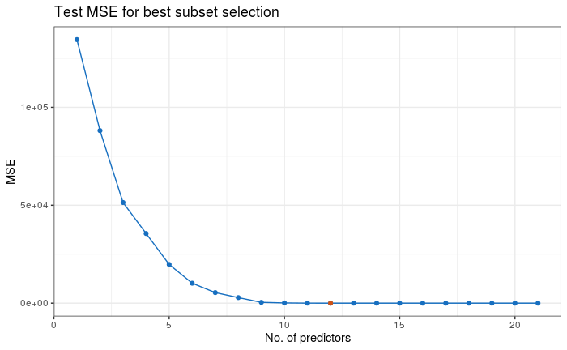

```r
## DATA
beta[c(5, 7, 10, 13, 17, 20)] = 0 # set even more beta's to zero

y <- X%*%beta + eps
data <- data.frame(X, y)

## TRAIN
set.seed(1)
regfit.train <- regsubsets(y ~ ., data[train, ], nvmax=20)
training.errors <- rep(0, p+1)
training.errors[1] <- mean((y[train] - mean(y[train]))^2) # null model (intercept only) ???
for(i in 1:p) {
  pred <- predict.regsubsets(regfit.train, data[train, ], id=i)
  training.errors[i+1] = mean((pred - y[train])^2)
}

## TEST
test.errors <- rep(0, p+1)
test.errors[1] <- mean((y[test] - mean(y[train]))^2) # null model (intercept only) ???
for(i in 1:p) {
  pred <- predict.regsubsets(regfit.train, data[test, ], id=i)
  test.errors[i+1] = mean((pred - y[test])^2)
}

tibble(
  p = 1:(p+1),
  error = test.errors
) %>%
  ggplot(aes(p, error)) +
  geom_point(color = ISLR_blue) +
  geom_line(color = ISLR_blue) +
  geom_point(data = tibble(p = which.min(test.errors), error = test.errors[p]),
             color = ISLR_orange) +
  labs(x = "No. of predictors", y = "MSE", title = "Test MSE for best subset selection")
```

### (f)

Check which model has the lowest test error:

```r
which.min(test.errors)
```

```
[1] 12
```

We see that the 12-variable model has the lowest test error. This means that 8 variables were excluded to obtain the optimal model.

The variables and coefficients of the 12-variable model are:

```r
round(coef(regfit.train, 12), 3)
```

```
(Intercept)         x.1         x.2         x.4         x.5         x.6         x.9        x.11        x.12        x.14
      0.002      -3.197      -4.306       2.403      -0.004       4.301       0.201       4.798      -1.501       4.709
       x.16        x.18        x.19
      3.298      -4.100      -2.010
```

```r
as.numeric(round(coef(regfit.train, 12)[-c(1, 10)], 1)) # x.15 is the 10th entry in the vector
```

```
 [1] -3.2 -4.3  2.4  0.0  4.3  0.2  4.8 -1.5  3.3 -4.1 -2.0
```

```r
beta[which(beta!=0)]
```

```
 [1] -3.2 -4.3  2.4  4.3  0.2  4.8 -1.5  4.7  3.3 -4.1 -2.0
```

The true model includes 11 variables; inspect the variables and coefficients of the 11-variable model to see how they compare to the true model:

```r
round(coef(regfit.train, 11), 1)
```

```
(Intercept)         x.1         x.2         x.4         x.6         x.9        x.11        x.12        x.14        x.16
        0.0        -3.2        -4.3         2.4         4.3         0.2         4.8        -1.5         4.7         3.3
       x.18        x.19
       -4.1        -2.0
```

The 11-variable model has the exact same variables as the true model. Inspect the coefficients to see if they are the same:

```r
as.numeric(round(coef(regfit.train, 11)[-1], 1))
```

```
 [1] -3.2 -4.3  2.4  4.3  0.2  4.8 -1.5  4.7  3.3 -4.1 -2.0
```

```r
beta[which(beta!=0)]
```

```
 [1] -3.2 -4.3  2.4  4.3  0.2  4.8 -1.5  4.7  3.3 -4.1 -2.0
```

The coefficients match exactly to one decimal place.

Compare the test R^2 of the 11- and 12- variable models:

```r
test.avg <- mean(y[test])
test.r2.11 <- 1 - test.errors[11] / mean((test.avg - y[test])^2)
test.r2.12 <- 1 - test.errors[12] / mean((test.avg - y[test])^2)
c(mod.11=test.r2.11, mod.12=test.r2.12)
```

```
   mod.11    mod.12
0.9999492 0.9999960
```

As we can see both R^2 values are extremely high, indicating that both models perform very well, with the 11-variable model matching almost exactly with the true model.

### (g)

Create a plot displaying $\sqrt{\sum_{j=1}^p(\beta_j - \beta_j^r)^2}$ for a range of values of $r$, where $\beta_j^r$ is the $j$th coefficient estimate for the best model containing $r$ coefficients. Comment on what you observe. How does this compare to the test MSE plot from (d)?

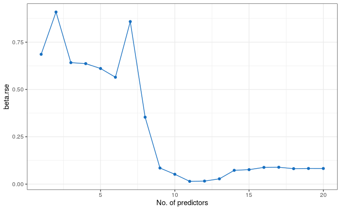

```r
beta.rse <- rep(0, p)
for(i in 1:p) {
  C <- coef(regfit.train, i)
  J <- as.numeric(c(gsub("x.", "", names(C[-1]))))
  beta.rse[i] <- sqrt(sum((beta[J] - C[-1])^2))
}

data.frame(p = 1:p, beta.rse) %>%
  ggplot(aes(p, beta.rse)) +
  geom_line(color = ISLR_blue) +
  geom_point(color = ISLR_blue) +
  labs(x = "No. of predictors")
```

The plot shows that models with 10 variables or more have very little difference between the $\beta$ coefficients. For less than ten variables the plot is not similar to the test MSE plot. This tells us that even though the test error decreases from $r$ = 1 to 10, the estimated coefficients aren’t necessarily closer to the true coefficients.

## Exercise 11

Split data and set up grids and functions for analysis:

```r
# Set seed:
set.seed(1)

# Data
n = nrow(Boston)
p = ncol(Boston[ , -1])
var.names <- names(Boston[-1])
train <- sample(n, 4*n/5) # 80%/20% train/test
test <- (-train)
MSE = c() ## test errors

# Ridge/Lasso
X <- model.matrix(Boston$crim ~ ., Boston[, -1])[, -1]
grid <- 10^seq(10, -2, length=100) # lambda values

# CV
k = 10
folds <- sample(1:k, nrow(Boston[train, ]), replace=TRUE)
cv.errors <- matrix(NA, k, p, dimnames=list(NULL, paste(1:13)))
predict.regsubsets <- function(object, newdata, id,...) {
  form <- as.formula(object$call[[2]])
  mat <- model.matrix(form, newdata)
  coefi <- coef(object, id=id)
  xvars <- names(coefi)
  mat[, xvars]%*%coefi
}
```

### (a)

#### Best Subset Selection

Use best subset selection and cross-validation (on the training set only) to select a model:

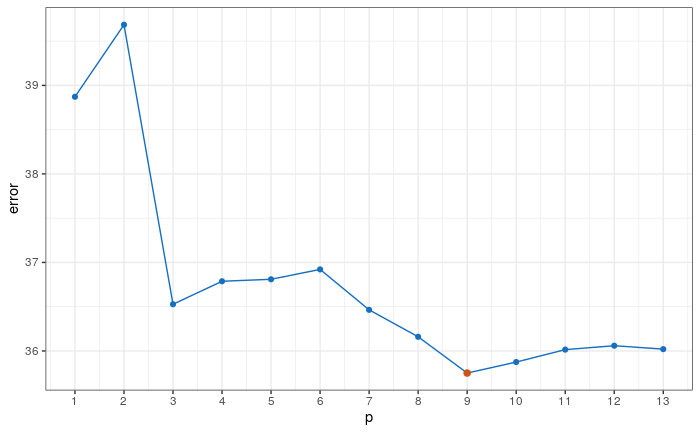

```r
for(j in 1:k) {
  best.fit <- regsubsets(crim ~ ., data=Boston[train, ][folds!=j, ], nvmax=p)
  for(i in 1:p) {
    pred <- predict.regsubsets(best.fit, Boston[train, ][folds==j, ], id=i)
    cv.errors[j, i] = mean((pred - Boston$crim[train][folds==j])^2)
  }
}
mean.cv.errors <- apply(cv.errors, 2, mean)
p.min <- which.min(mean.cv.errors)

# Plot errors
data.frame(p = 1:p, error = mean.cv.errors) %>%
  ggplot(aes(p, error)) +
  geom_line(color = ISLR_blue) +
  geom_point(color = ISLR_blue) +
  geom_point(data = data.frame(x = which.min(mean.cv.errors), y = mean.cv.errors[which.min(mean.cv.errors)]),
             aes(x, y),
             color = ISLR_orange, size = 2) +
  scale_x_continuous(breaks = 1:p)
```

Best subset selection on the training set with cross-validation has chosen the 9-variable model as the model with lowest CV error.

To calculate the test error, we use best subset selection on the training set, then make predictions on the test set using the 9-variable model:

```r
reg.best <- regsubsets(crim ~ ., data=Boston[train, ], nvmax=p)
reg.best.pred <- predict(reg.best, Boston[test, ], id=p.min)
reg.best.test.error <- mean((reg.best.pred - Boston$crim[test])^2)
MSE = c(MSE, reg.best=reg.best.test.error)
reg.best.test.error
```

```
[1] 69.0607
```

For the final model, perform best subset selection on the whole data set and obtain coefficients for the 9-variable model:

```r
reg.best <- regsubsets(crim ~ ., data=Boston, nvmax=p)
reg.best.omit <- names(coef(reg.best, p.min)[-1])
round(coef(reg.best, p.min), 3)
```

```
(Intercept)          zn       indus         nox         dis         rad     ptratio       black       lstat        medv
     19.125       0.043      -0.099     -10.466      -1.003       0.540      -0.271      -0.008       0.118      -0.181
```

The variables omitted by best subset selection are:

```r
var.names[!var.names %in% names(coef(reg.best, p.min)[-1])]
```

```
[1] "chas" "rm"   "age"  "tax"
```

#### Ridge Regression

Use cross-validation to choose an optimal $\lambda$ for ridge regression:

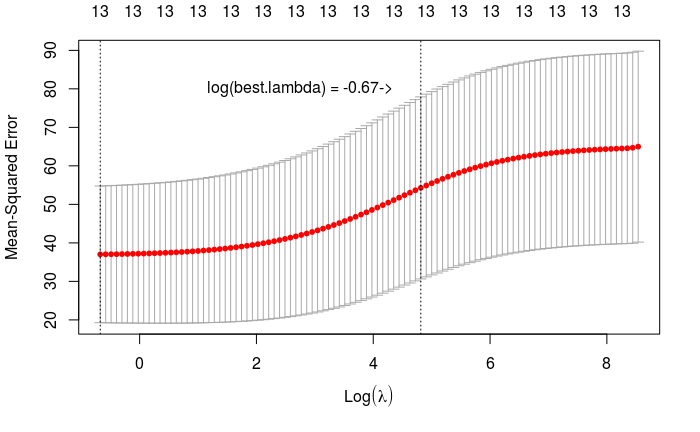

```r
set.seed(1)
cv.out <- cv.glmnet(X[train, ], Boston$crim[train], alpha=0)
best.lam <- cv.out$lambda.min

plot(cv.out)
text(4.5, 80, pos=2, paste0("log(best.lambda) = ", round(log(best.lam), 2), "->"))
```

Calculate the test error of ridge regression using the optimal $\lambda$ found by cross-validation:

```r
ridge.train <- glmnet(X[train, ], Boston$crim[train], alpha=0, lambda=best.lam)
ridge.pred <- predict(ridge.train, alpha=0, newx=X[test, ])
ridge.test.error <- mean((ridge.pred - Boston$crim[test])^2)
MSE = c(MSE, ridge=ridge.test.error)
ridge.test.error
```

```
[1] 70.70553
```

Generate a ridge regression on all of the data, then report the coefficients of the best model as obtained by cross-validation:

```r
ridge <- glmnet(X, Boston$crim, alpha=0, lambda=best.lam)
ridge.coef <- predict(ridge, type="coefficients")[1:p+1, ]
round(ridge.coef, 3)
```

```
     zn   indus    chas     nox      rm     age     dis     rad     tax ptratio   black   lstat    medv
  0.033  -0.082  -0.738  -5.569   0.337   0.002  -0.712   0.428   0.003  -0.141  -0.008   0.142  -0.141
```

Ridge regression does not perform feature selection, but the variables with small coefficients are:

```r
sort(abs(ridge.coef))[1:3]
```

```
        age         tax       black
0.001976858 0.003196670 0.008452392
```

Best subset selection omitted `age` and `tax`, while ridge regression has assigned these variables a near-zero coefficient. However, the methods disagree on `chas` and `rm`. Best subset selection omitted them, while ridge regression assigned them a non-zero coefficient. Ridge regression also assigned a near-zero coefficient to `black`. While Best subset selection included the `black` variable in the model, it also assigned a near-zero coefficient, which happens to be identical to the ridge regression coefficient.

#### Lasso

Use cross-validation to choose an optimal $\lambda$ for the lasso:

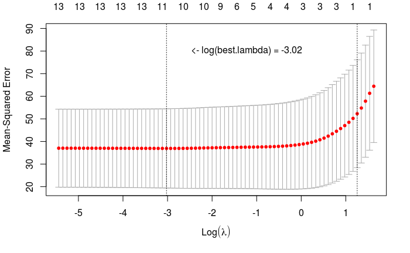

```r
set.seed(1)
lasso.cv <- cv.glmnet(X[train, ], Boston$crim[train], alpha=1)
best.lam <- lasso.cv$lambda.min

plot(lasso.cv)
text(-2.6, 80, pos=4, paste0("<- log(best.lambda) = ", round(log(best.lam), 2)))
```

Calculate the test error of the lasso using the optimal $\lambda$ found by cross-validation:

```r
lasso.train <- glmnet(X[train, ], Boston$crim[train], alpha=1, lambda=best.lam)
lasso.pred <- predict(lasso.train, alpha=1, newx=X[test, ])
lasso.test.error = mean((lasso.pred - Boston$crim[test])^2)
MSE = c(MSE, lasso=lasso.test.error)
lasso.test.error
```

```
[1] 69.65218
```

Generate a lasso model on all of the data, then report the coefficients of the best model as obtained by cross-validation:

```r
lasso <- glmnet(X, Boston$crim, alpha=1, lambda=best.lam)
lasso.coef <- predict(lasso, type="coefficients")[1:p+1, ]
round(lasso.coef, 3)
```

```
     zn   indus    chas     nox      rm     age     dis     rad     tax ptratio   black   lstat    medv
  0.036  -0.070  -0.591  -7.133   0.239   0.000  -0.796   0.515   0.000  -0.193  -0.008   0.125  -0.160
```

The variables omitted by the lasso are:

```r
var.names[!var.names %in% names(lasso.coef[which(lasso.coef!=0)])]
```

```
[1] "age" "tax"
```

The variables omitted by the lasso model are `age` and `tax`. This is consistent with the best subset selection model which also omitted them, and the ridge regression model which assigned them near-zero coefficients. The lasso model also assigned a near-zero coefficient to the `black` variable. Like ridge regression, the lasso model also assigns non-zero coefficients to `chas` and `rm`, while the best subset selection model omitted them.

#### PCR

```r
set.seed(1)
pcr.fit <- pcr(crim ~ ., data=Boston, subset=train, scale=TRUE, validation="CV")
summary(pcr.fit)
```

```
Data:   X dimension: 404 13
    Y dimension: 404 1
Fit method: svdpc
Number of components considered: 13

VALIDATION: RMSEP
Cross-validated using 10 random segments.
       (Intercept)  1 comps  2 comps  3 comps  4 comps  5 comps  6 comps  7 comps  8 comps  9 comps  10 comps  11 comps
CV           8.062    6.718    6.711    6.222    6.174    6.190    6.222    6.212    6.103    6.114     6.108     6.126
adjCV        8.062    6.714    6.707    6.215    6.168    6.184    6.215    6.203    6.093    6.104     6.097     6.116
       12 comps  13 comps
CV        6.104     6.035
adjCV     6.092     6.023

TRAINING: % variance explained
      1 comps  2 comps  3 comps  4 comps  5 comps  6 comps  7 comps  8 comps  9 comps  10 comps  11 comps  12 comps  13 comps
X       48.21    60.84    70.12    76.82    82.98    87.85    91.09    93.38    95.28     96.99     98.38     99.48    100.00
crim    31.86    32.09    42.14    42.99    43.02    43.03    43.28    45.29    45.61     45.91     45.93     46.70     47.96
```

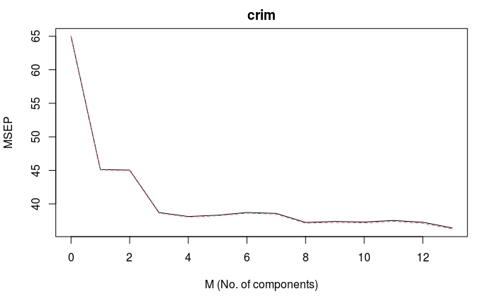

```r
validationplot(pcr.fit, val.type="MSEP", xlab="M (No. of components)")
```

In the above plot, the MSE decrease as $M$ increases. We will choose $M=9$ components, as this captures 95.28% of the variance in the predictors, while omitting 4 of them.

Calculate the test error for a 9-component PCR model:

```r
pcr.pred <- predict(pcr.fit, Boston[test, ], ncomp=9)
pcr.test.error <- mean((pcr.pred - Boston$crim[test])^2)
MSE = c(MSE, pcr = pcr.test.error)
pcr.test.error
```

```
[1] 73.64572
```

#### PLS

```r
set.seed(1)
pls.fit <- plsr(crim ~ ., data=Boston, subset=train, scale=TRUE, validation="CV")
summary(pls.fit)
```

```
Data:   X dimension: 404 13
    Y dimension: 404 1
Fit method: kernelpls
Number of components considered: 13

VALIDATION: RMSEP
Cross-validated using 10 random segments.
       (Intercept)  1 comps  2 comps  3 comps  4 comps  5 comps  6 comps  7 comps  8 comps  9 comps  10 comps  11 comps
CV           8.062    6.519    6.125    6.088    6.087    6.060    6.037    6.054    6.034    6.032     6.034     6.035
adjCV        8.062    6.515    6.118    6.076    6.074    6.049    6.025    6.039    6.022    6.020     6.022     6.022
       12 comps  13 comps
CV        6.035     6.035
adjCV     6.023     6.023

TRAINING: % variance explained
      1 comps  2 comps  3 comps  4 comps  5 comps  6 comps  7 comps  8 comps  9 comps  10 comps  11 comps  12 comps  13 comps
X       47.71    57.30    62.55    71.54    77.84    80.23    82.98    86.82    90.16     94.06     96.78     98.51    100.00
crim    36.12    44.77    46.64    47.24    47.52    47.85    47.93    47.95    47.96     47.96     47.96     47.96     47.96
```

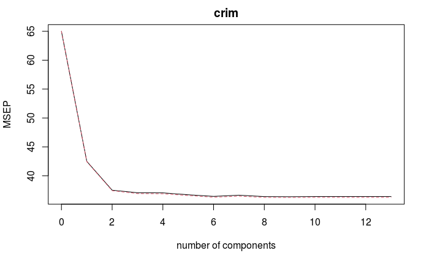

```r
validationplot(pls.fit, val.type="MSEP")
```

In the above plot, the error decrease to the minimum very quickly. While a small number of components (low $M$) give a low training error, the components don’t capture as much of the variance as the PCR model did. For example with $M=9$ components, the PLS model captures 90.16% of the variance in the predictors. However, for 9 components, PLS captures more of the variance in the response than the PCR model does. This is expected as the PLS method is dependent on the response. Choose a 9-component PLS model and calculate the test error:

```r
pls.pred <- predict(pls.fit, Boston[test, ], ncomp=9)
pls.test.error <- mean((pls.pred - Boston$crim[test])^2)
MSE = c(MSE, pls=pls.test.error)
pls.test.error
```

```
[1] 69.11755
```

We see that the PLS test error is lower than the PCR error.

### (b)

Inspect the test errors of the models:

```r
sort(MSE)
```

```
reg.best      pls    lasso    ridge      pcr
69.06070 69.11755 69.65218 70.70553 73.64572
```

We see that all of the models performed comparatively on test MSE, but PCR has a slightly larger test error than the others.

We can also calculate the test $R^2$ values:

```r
# For RSS, R^2 can be calculated using 1 - sum((crim[test] - ridge.pred)^2)/sum((crim[test] - test.avg)^2). For MSE the below is used:
test.avg <- mean(Boston$crim[test])
reg.best.test.r2 <- 1 - reg.best.test.error / mean((test.avg - Boston$crim[test])^2)
ridge.test.r2 <- 1 - ridge.test.error / mean((test.avg - Boston$crim[test])^2)
lasso.test.r2 <- 1 - lasso.test.error / mean((test.avg - Boston$crim[test])^2)
pcr.test.r2 <- 1 - pcr.test.error / mean((test.avg - Boston$crim[test])^2)
pls.test.r2 <- 1 - pls.test.error / mean((test.avg - Boston$crim[test])^2)
test.r2 <- c(reg.best=reg.best.test.r2, ridge=ridge.test.r2, lasso=lasso.test.r2, pcr=pcr.test.r2, pls=pls.test.r2)
sort(test.r2, decreasing = TRUE)
```

```
 reg.best       pls     lasso     ridge       pcr
0.3706930 0.3701750 0.3653033 0.3557047 0.3289126
```

We see that the best subset model has the best $R^2$, indicating that the model captures about 37% of the variability of the data.

### (c)

This is discussed throughout part (a). In general, all of the final models excluded some features or reduced the dimensionality as applicable (ridge regression applied near-zero coefficients to some variables). This would suggest that using a simpler model helps reduce overfitting on the training data, allowing a better performance on the test data.

[^1]: James G, Witten D, Hastie T, Tibshirani R (2013). *An Introduction to Statistical Learning: with Applications in R*. Springer, 1st edition.